# On Diffusion approximations of the Kinetic Langevin Equation

joint work with Yoichiro Mori and Chanoknun Sintavanuruk

Truong-Son Van

Fulbright University Vietnam  
Vietnam National University Ho Chi Minh City (Fall 2025)

April 10, 2025

# Kinetic Langevin

$$\begin{cases}
d X_t &= Y_t dt \\
d Y_t &= (- Y_t + b )dt + dW_t
\end{cases}$$

Corresponding Fokker-Planck equation

$$\partial_{t} \rho + \nabla_x \cdot (v\rho) + \nabla_{v}\cdot(( b-v)\rho) - \Delta_{v}\rho = 0 \,.$$

# Original motivation

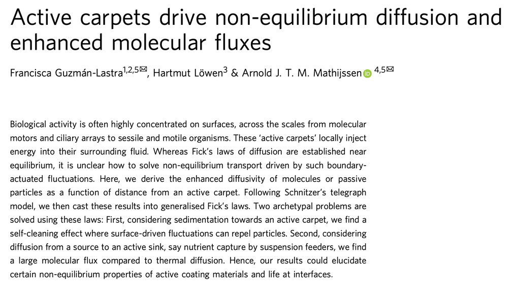

## Steady states of particles in incompressible flow

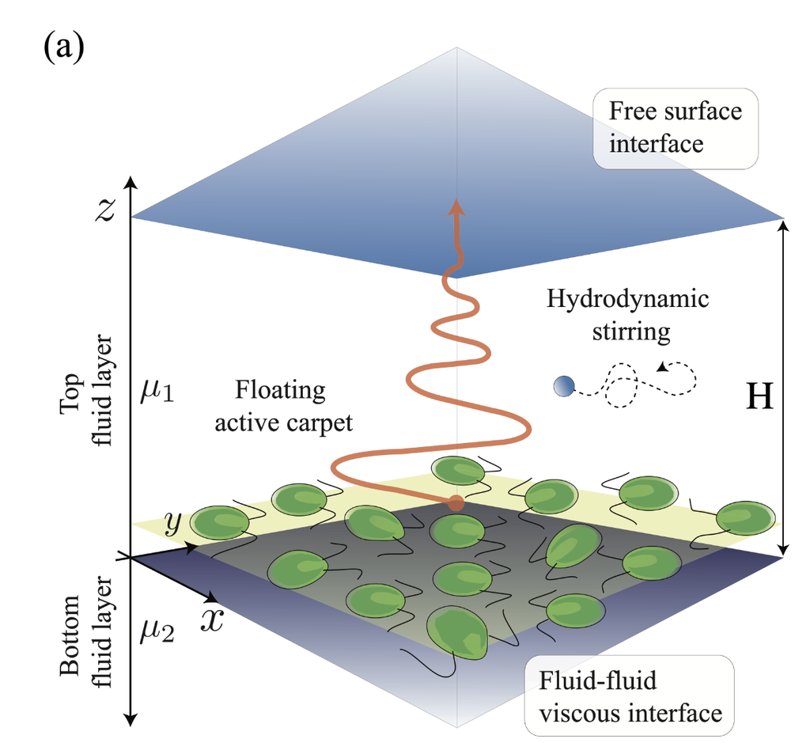

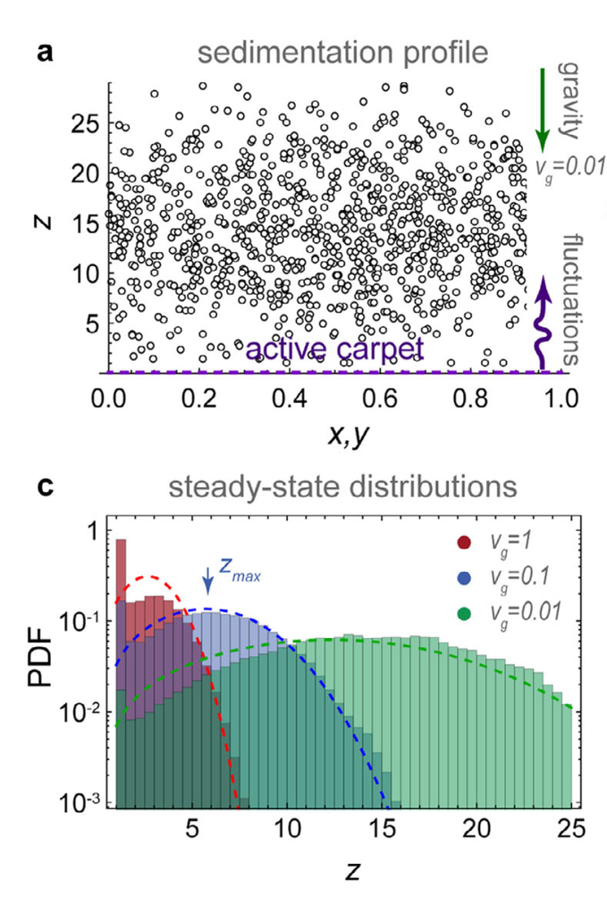

Source: Guzmán-Lastra, Löwen, and Mathijssen (2021)

[video not shown]

Source: Guzmán-Lastra, Löwen, and Mathijssen (2021)

## Problem

- The authors of the paper consider passive tracers, whose distribution is described by advection-diffusion equation
  $$\partial_t \rho + \nabla \cdot (\bf{v} \rho) = \kappa \Delta \rho$$
  $$\nabla \cdot \bf{v} = 0$$
- Unverified assumption

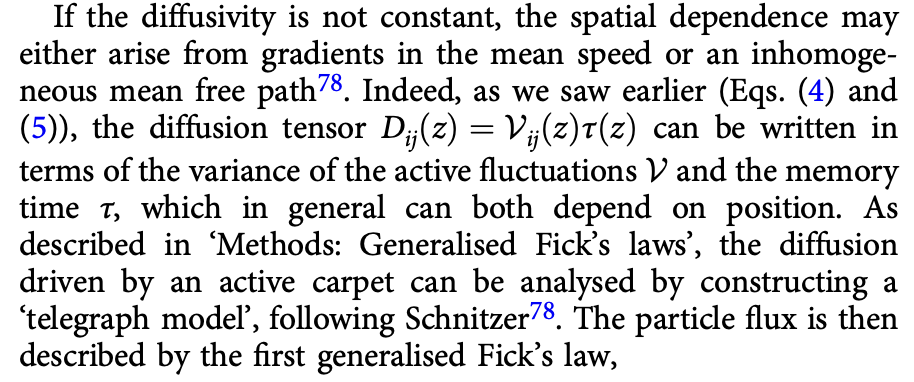

## How can one capture the non-uniformity in this system?

# Climate

[figure not shown]

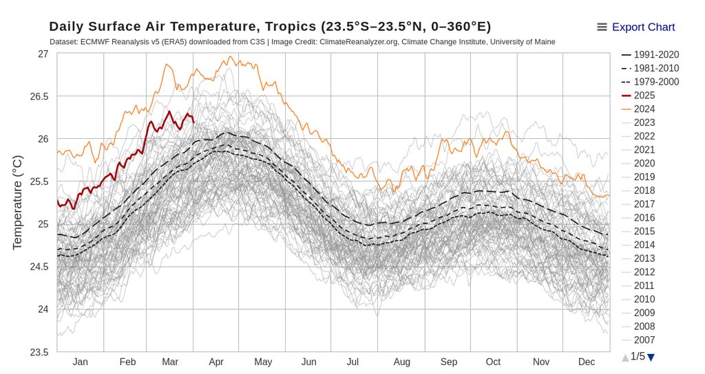

Source: https://climatereanalyzer.org/clim/t2_daily/?dm_id=tropics

# Fast-slow system

### General

$$\begin{cases}
\dot X^\epsilon_t = f(X^\epsilon_t, Y^\epsilon_t, t) \\
Y^\epsilon_t \sim \xi^\epsilon_{t/\epsilon}
\end{cases}$$

### General

$$\begin{cases}
\dot X^\epsilon_t = f(X^\epsilon_t, Y^\epsilon_t, t) \\
Y^\epsilon_t \sim \xi^\epsilon_{t/\epsilon}
\end{cases}$$

### Random fast system

Let $\tau = t/\epsilon$ and $\xi^\epsilon$ satisfies
$$d \xi^\epsilon_{\tau} = g(X^\epsilon_{\tau}, \tau)d\tau + h(X^\epsilon_{\tau}, \tau) dW_{\tau}$$
$$d\tau = \frac{dt}{\epsilon} \qquad d W_{\tau} = d W_{t/\epsilon} \sim \frac{1}{\sqrt\epsilon} dW_t$$

### General

$$\begin{cases}
\dot X^\epsilon_t = f(X^\epsilon_t, Y^\epsilon_t, t) \\
Y^\epsilon_t \sim \xi^\epsilon_{t/\epsilon}
\end{cases}$$

### Random fast system

$$\begin{cases}
d X^\epsilon_t &= f(X^\epsilon, Y^\epsilon_t, t) dt \\
\epsilon d Y^\epsilon_t &= g(X^\epsilon_t, Y^\epsilon_t,t)dt + \sqrt{\epsilon} h(X^\epsilon_t, Y^\epsilon_t,t) dW_t
\end{cases}$$

### General

$$\begin{cases}
\dot X^\epsilon_t = f(X^\epsilon_t, Y^\epsilon_t, t) \\
Y^\epsilon_t \sim \xi^\epsilon_{t/\epsilon}
\end{cases}$$

### Random fast system

$$\begin{cases}
d X^\epsilon_t &= f(X^\epsilon, Y^\epsilon_t, t) dt \\
\epsilon d Y^\epsilon_t &= g(X^\epsilon_t, Y^\epsilon_t,t)dt + \sqrt{\epsilon} h(X^\epsilon_t, Y^\epsilon_t,t) dW_t
\end{cases}$$

### Kinetic Langevin

$$\begin{cases}
d X^\epsilon_t &= Y^\epsilon_t dt \\
\epsilon d Y^\epsilon_t &= (- Y^\epsilon_t + b(X^\epsilon_t, t) )dt + \sqrt{2 \epsilon} dW_t
\end{cases}$$

## Problem

Expensive to simulate

## Averaging Principle

**Under appropriate regularity conditions**

Suppose
$$\lim_{\epsilon \to 0} \lim_{T \to \infty} \frac{1}{T} \int_0^T f(x, Y^\epsilon_s,t) \, ds = \bar f(x, t) \,.$$
Then $X^\epsilon \to X$, where
$$\dot X_t = \bar f(X_t, t) \,.$$

*Random Perturbations of Dynamical Systems*, Freidlin and Wentzell (2012)

## Rate of convergence

**Under appropriate regularity conditions**

Given $T>0$ and $\varphi \in C^\infty(\mathbb{T}^n)$. There exists a constant $C$ such that
$$\begin{equation}
\sup_{t \in [0, T]} \mathbb E \left| X^\epsilon_t - X_t \right| \leq C\epsilon^{1/2}
\end{equation}$$
and
$$\begin{equation}
\sup_{t\in [0, T]} \left| \mathbb E \varphi(X^\epsilon_t) - \mathbb E \varphi(X_t) \right|
\leq C \epsilon \,.
\end{equation}$$

Röckner, Sun, and Xie (2019) (for a much more general system)

## Idea

- Write the Fokker-Planck equation

$$\partial_{t} \rho^\epsilon + \nabla_x \cdot (f \rho^\epsilon) + \epsilon^{-1}\nabla_{v}\cdot(g \rho^\epsilon) - \epsilon^{-1} \sum_{ij} H_{ij}\frac{\partial^2}{\partial v_i \partial v_j} \rho^\epsilon = 0 \,.$$

- Use hypoellipticity to control $\nabla_x \rho^\epsilon$ and $D^2_x \rho^\epsilon$

# Can we **cheaply** approximate the system **more efficiently**?

## Previous works

**Hasselmann’s scheme (Hasselmann (1976)) – Nobel 2021**

Let $H^\epsilon$ be solution of
$$dH^\epsilon_t = \bar f (H^\epsilon_t, t) dt + \sqrt{\epsilon} \sigma(H^\epsilon_t) dW_t$$
where
$$\sigma^* \sigma (x) = a (x)$$
and $a(x)$ is the correlation matrix satisfying
$$a_{ij}(x) = \lim_{\epsilon \to 0} \lim_{T\to \infty} \mathbb{E} \int_0^T (f_i(x, \xi^\epsilon_s, t) - \bar f_i(x,t)) \, ds \int_0^T (f_j(x, \xi^\epsilon_s) - \bar f_j(x,t)) \, ds \,.$$

**Conjecture**

$$\sup_{0\leq t \leq T} \mathbb{E} | X^\epsilon_t - H^\epsilon_t | \leq \epsilon\,.$$

**Theorem (Bakhtin and Kifer (2004))**

$$\sup_{0\leq t \leq T}\mathbb{E} | X^\epsilon_t - H^\epsilon_t | \leq \epsilon^{1/2 + \delta} \,.$$
for any $\delta \in (0,1/(18+8n))$.

**Idea**

1. Use the central limit theorem of Khas’minskii (1966)
   $$\frac{ X^\epsilon_t - X_t}{\sqrt \epsilon} \to R_t$$
2. Approximate $X^\epsilon_t$ and $H^\epsilon_t$ by
   $$K^\epsilon_t = X_t + \sqrt{\epsilon} R_t \,.$$

# It’s been almost 50 years since the conjecture. Why should we believe such claim?

## Kinetic Langevin

$$\begin{cases}
d X^\epsilon_t &= Y^\epsilon_t dt \\
\epsilon d Y^\epsilon_t &= (- Y^\epsilon_t + b(X^\epsilon_t, t) )dt + \sqrt{2 \epsilon} dW_t
\end{cases}$$

## Case $b= 0$

$$X^\epsilon_t =
\epsilon(1 - e^{-t/\epsilon}) Y^\epsilon_0 +
\sqrt{2\epsilon} W_t - \sqrt{2\epsilon} \int_0^t e^{-(t-s)/\epsilon} \, dW_s \,.$$

$$H^\epsilon_t = \sqrt{2\epsilon} W_t$$

Subtract the above from each other and by Ito isometry

$$\begin{equation*}
\mathbb E \left| X^\epsilon_t - H^\epsilon_t \right|^2
\leq C\epsilon^2 + 2\epsilon \int_0^t e^{-2(t-s)/\epsilon} \, ds \leq C \epsilon^2
\end{equation*}$$

So
$$\sup_{0\leq t \leq T} \mathbb{E} | X^\epsilon_t - H^\epsilon_t | \leq \epsilon$$

# Direct approach on Kinetic Langevin

## Kinetic Langevin

$$\begin{cases}
d X^\epsilon_t &= Y^\epsilon_t dt \\
\epsilon d Y^\epsilon_t &= (- Y^\epsilon_t + b(X^\epsilon_t, t) )dt + \sqrt{2 \epsilon} dW_t
\end{cases}$$

Integral form

$$\begin{align*}
X^\epsilon_t
& = X^\epsilon_0 + \int_0^t Y^\epsilon_s \, ds \\
& = X^\epsilon_0 +
\int_0^t \left( e^{-s/\epsilon} Y_0 + \frac{1}{\epsilon}\int_0^s e^{-(s-r)/\epsilon} b(X^\epsilon_r, r) \, dr \right) ds \nonumber \\
& \qquad + \sqrt{\frac{2}{\epsilon}} \int_0^t\int_0^s e^{-(s-r)/\epsilon} \, dW_r \, ds \,.
\label{eq:Langevin-solution}
\end{align*}$$

Rewirte the equation for $X^\epsilon_t$
$$\begin{align*}
dX^\epsilon_t & = \left( A(X^\epsilon_t,t) + V^\epsilon_t \right) dt\,, \\
dV^\epsilon_t & = -\frac{V^\epsilon_t}{\epsilon} \, dt + \sqrt{\frac 2 \epsilon} dW_t \,,
\end{align*}$$
where
$$\begin{align*}
A(X^\epsilon_t,t) &= b_0 e^{-t/\epsilon} + \frac{1}{\epsilon} \int_0^t e^{-(t-s)/\epsilon} b(X^\epsilon_s,s) \, ds \\
& = b(x(t),t) \\
&- \int_0^t e^{-(t-s)/\epsilon} \left(\partial_t b(X^\epsilon_s,s) + D b(X^\epsilon_s,s)\, \dot X^\epsilon_s \right) \, ds \\
& \approx b(X^\epsilon_t,t) - \epsilon \left( \partial_t b(X^\epsilon_t,t) + Db(X^\epsilon_t,t) \, \dot X^\epsilon_t \right)
\end{align*}$$

$$dX^\epsilon_t \approx b(X^\epsilon_t,t) dt - \epsilon \left( \partial_t b(X^\epsilon_t,t) + Db(X^\epsilon_t,t) \, \dot X^\epsilon_t \right) dt + V^\epsilon_t dt$$

So, $\dot X^\epsilon_t \approx b(X^\epsilon_t,t)$.

**Proposed scheme**

$$\begin{align*}
dZ^\epsilon_t
&= b(Z^\epsilon_t,t) dt - \textcolor{red}{\epsilon} \left( \partial_t b(Z^\epsilon_t,t) + Db(Z^\epsilon_t,t) \, \dot Z^\epsilon_t \right) dt
+ \sqrt{2 \epsilon} dW_t \\
&= F(Z^\epsilon_t,t) \, dt
+ \sqrt{2 \epsilon} dW_t
\end{align*}$$
where $F = b - \epsilon (\partial_t b + D_x b b)$.

Fokker-Planck equation

$$\begin{equation}
\partial_t u^\epsilon + \nabla_x \cdot \left(
F u^\epsilon\right) - \epsilon \Delta_x u^\epsilon = 0
\label{eq:PDEApprox}
\end{equation}$$

## (Surprised) Relation to Turbulence

From *Introduction to Turbulent Transport of Particles, Temperature and Magnetic Fields* by Rogachevskii (2021)

Using Feynman’s path integral, one may formally derive

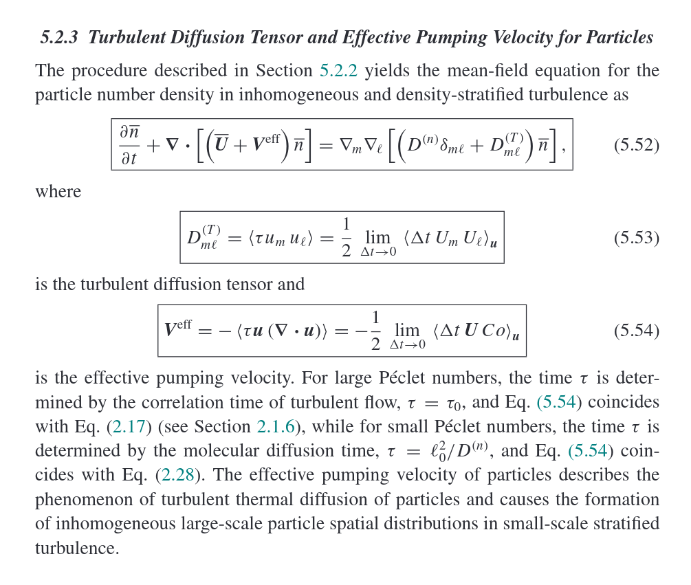

# Result

**Theorem? (Mori, Sintavanuruk, V., 2025+)**

Assume $Y^\epsilon_0 \sim \mathcal N(b(X_0, 0), 1)$ and smooth velocity field $b$. For each $T>0$, there exists $C>0$ such that
$$\begin{equation}
\sup_{t \in [0,T]}\mathbb E \left| X^\epsilon_t - Z^\epsilon_t \right| \leq C \epsilon \,.
\end{equation}$$
Furthermore, for every $\varphi \in C^\infty(\mathbb T^n)$, there exists $C > 0$ such that
$$\begin{equation}
\sup_{t \in [0,T]}\left|\mathbb E \left[\varphi(X^\epsilon_t) - \varphi(Z^\epsilon_t)\right] \right|
\leq C \epsilon^{2}\,.
\end{equation}$$

**Conjecture for Hasselmann’s scheme follows as corollary**

$$\sup_{0\leq t \leq T} \mathbb E | X^\epsilon_t - H^\epsilon_t | \leq \epsilon.$$

## Proof idea

- Combination of using the integral form of the SDE to carefully control

$$A(X^\epsilon_t, t) - F(Z^\epsilon_t,t)$$

Pros: avoid using hypoellipticity

Cons: assume regularity of velocity field

## Large time simulation

Original system

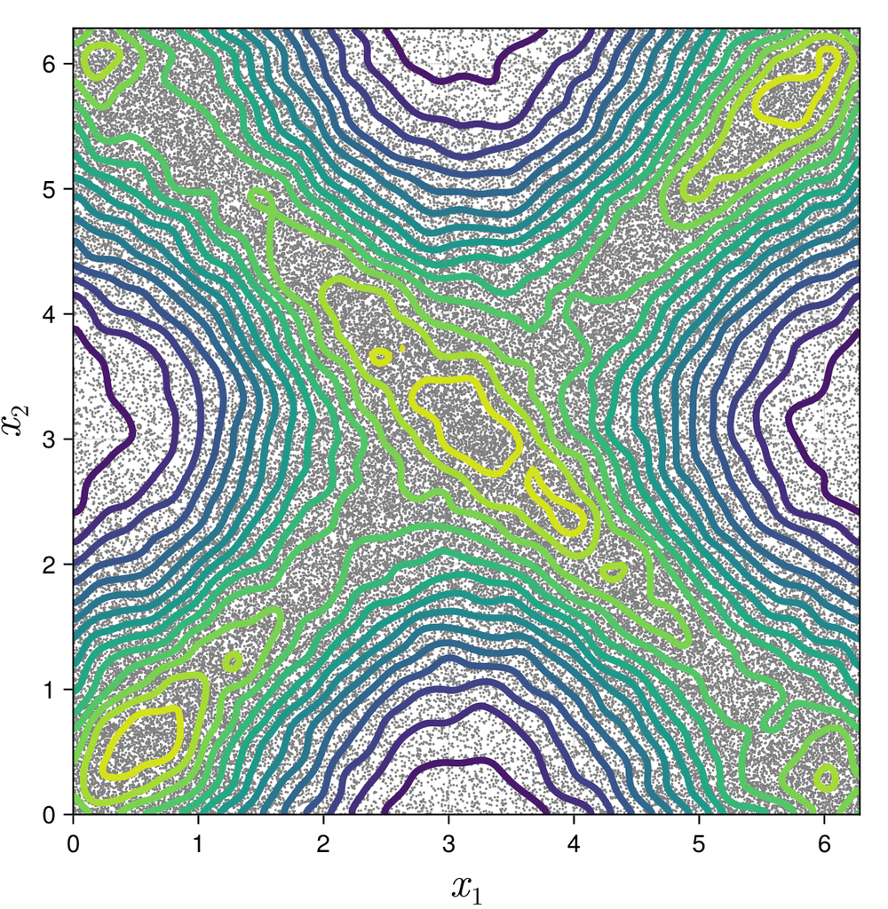

## Large time simulation

Top Left: MSV

Top Right: Hasselmann

Bottom Left: Bakhtin-Kifer

Bottom Right: Li-Xie-Wang (non-diffusion)

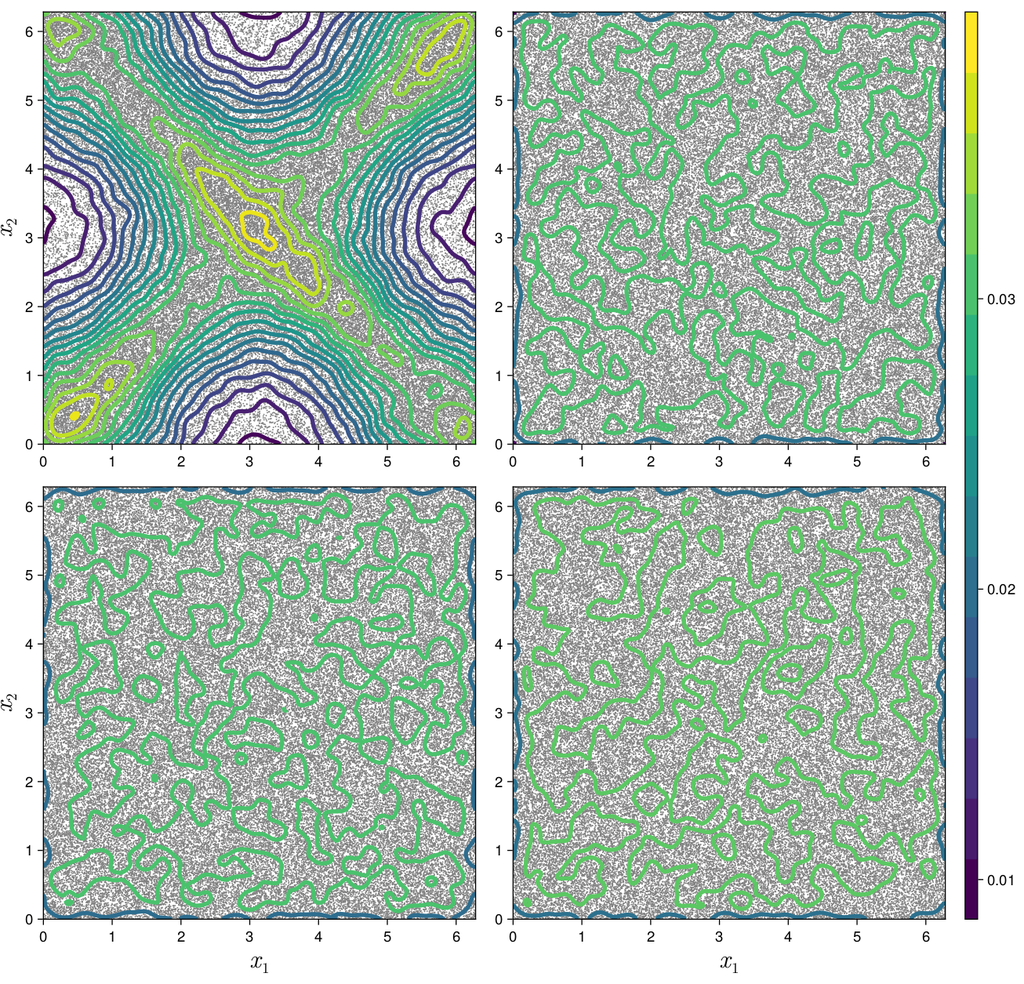

## Future

- Rigorous proof/disproof of large time behavior
- Generalization
- Different scaling regimes
- PDE proof
- Enhanced diffusion from homogenization of inertial particles
- Apply to physical models

## Thank you!

Bakhtin, Victor, and Yuri Kifer. 2004. “Diffusion Approximation for Slow Motion in Fully Coupled Averaging.” *Probability Theory and Related Fields* 129 (2): 157–81. https://doi.org/10.1007/s00440-003-0326-7.

Freidlin, Mark I., and Alexander D. Wentzell. 2012. *Random Perturbations of Dynamical Systems*. Third. Vol. 260. Grundlehren Der Mathematischen Wissenschaften [Fundamental Principles of Mathematical Sciences]. Springer, Heidelberg. https://doi.org/10.1007/978-3-642-25847-3.

Guzmán-Lastra, Francisca, Hartmut Löwen, and Arnold J. T. M. Mathijssen. 2021. “Active Carpets Drive Non-Equilibrium Diffusion and Enhanced Molecular Fluxes.” *Nature Communications* 12 (1): 1906. https://doi.org/10.1038/s41467-021-22029-y.

Hasselmann, K. 1976. “Stochastic Climate Models Part I. Theory.” *Tellus* 28 (6): 473–85. https://doi.org/10.1111/j.2153-3490.1976.tb00696.x.

Khas’minskii, R. Z. 1966. “On Stochastic Processes Defined by Differential Equations with a Small Parameter.” *Theory of Probability & Its Applications* 11 (2): 211–28. https://doi.org/10.1137/1111018.

Röckner, Michael, Xiaobin Sun, and Longjie Xie. 2019. “Strong and Weak Convergence in the Averaging Principle for SDEs with H\"older Coefficients,” no. arXiv:1907.09256 (July). http://arxiv.org/abs/1907.09256.

Rogachevskii, Igor. 2021. *Introduction to Turbulent Transport of Particles, Temperature and Magnetic Fields: Analytical Methods for Physicists and Engineers*. 1st ed. Cambridge University Press. https://doi.org/10.1017/9781009000918.